```python
import numpy as np
from sklearn.preprocessing import scale, robust_scale, minmax_scale
from scipy import stats
import scipy.stats
import pandas as pd
import statsmodels.api as sm
import matplotlib
import matplotlib.pyplot as plt
import seaborn as sns
import statsmodels.formula.api as smf
from statsmodels.stats.proportion import proportions_ztest
from statsmodels.formula.api import ols
from statsmodels.tools.eval_measures import rmse
from statsmodels.stats.outliers_influence import variance_inflation_factor
from sklearn.linear_model import LinearRegression
from sklearn.feature_selection import RFE
from sklearn.preprocessing import scale
from statsmodels.graphics.tsaplots import plot_acf,plot_pacf
from statsmodels.tsa.arima_model import ARIMA
from datetime import datetime

%matplotlib inline
matplotlib.rc('font', family='NanumBarunGothic')
plt.rcParams['axes.unicode_minus']=False
```

# 데이터 불러오기

```python
ds_bo = pd.read_excel('./Downloads/4. 빅데이터분석_실습화일.xlsx',sheet_name='종실1.BOSTON_HOUSING',encoding='CP949')
ds_bo.head()
#관측치 506개, 종속변수 MEDV 1개, 설명변수 13개
```

|  | MEDV | CRIM | ZN | INDUS | CHAS | NOX | RM | AGE | DIS | RAD | TAX | PTRATIO | B | LSTAT |
| --- | --- | --- | --- | --- | --- | --- | --- | --- | --- | --- | --- | --- | --- | --- |
| 0 | 24.000000 | 0.00632 | 18.0 | 2.31 | 0 | 0.538 | 6.575 | 65.199997 | 4.0900 | 1 | 296 | 15.300000 | 396.899994 | 4.98 |
| 1 | 21.600000 | 0.02731 | 0.0 | 7.07 | 0 | 0.469 | 6.421 | 78.900002 | 4.9671 | 2 | 242 | 17.799999 | 396.899994 | 9.14 |
| 2 | 34.700001 | 0.02729 | 0.0 | 7.07 | 0 | 0.469 | 7.185 | 61.099998 | 4.9671 | 2 | 242 | 17.799999 | 392.829987 | 4.03 |
| 3 | 33.400002 | 0.03237 | 0.0 | 2.18 | 0 | 0.458 | 6.998 | 45.799999 | 6.0622 | 3 | 222 | 18.700001 | 394.630005 | 2.94 |
| 4 | 36.200001 | 0.06905 | 0.0 | 2.18 | 0 | 0.458 | 7.147 | 54.200001 | 6.0622 | 3 | 222 | 18.700001 | 396.899994 | 5.33 |

```python
ds_bo_y=ds_bo["MEDV"]
ds_y=ds_bo["MEDV"]
ds_bo_x=ds_bo.drop("MEDV", axis=1, inplace=False)
print("목표변수 데이터 크기:{}".format(ds_bo_y.shape))
print("설명변수 데이터 크기:{}".format(ds_bo_x.shape))
```

```
목표변수 데이터 크기:(506,)
설명변수 데이터 크기:(506, 13)
```

# 과제정의 - 변수 설명, 예측

```python
# 변수 설명, 예측 - 기본적으로 선형 가정, 실제로는 구간마다 증감 폭이 다르고 비선형 예상
# 범죄율 CRIM이 낮을수록
# 주거지 비율 ZN이 높을수록 = ZN은 주거지(25k ft이상의 큰 집의 비율)
# 비소매업 비율(비주거 상업지역? 공업지 비율)INDUS가 낮을수록
# 찰스강이 보일수록, CHAS가 1일수록, 높을수록(보이면1 안보이면0)
# NOX 산화질소농도가 낮을수록?(높을수록 공업지일 확률이 높으나, 차가 많은 번화가도 높을 수 있다.)
# RM(주거당 평균 객실수)가 높을수록
# AGE(노후 건물비율)가 낮을수록? - 번화가의 경우 노후 건물 비율이 높을 수 있음
# DIS(중심지(노동센터)접근거리)가 낮을수록 가까울 수록
# RAD(고속도로 접근 편이성 지수)가 높을수록? - 너무 가까우면 소음, 매연 등의 부작용
# TAX(재산세율)이 높을수록
# PTRATIO(마을당 교사비율)이 높을수록
# B(흑인인구비율)이 낮을수록
# LSTAT(저소득층비율)이 낮을수록

# 집값, MEDV(주택가격중앙값)이 높을 것이라 예상
```

# 분석계획

구분 분석기법 시나리오/가설 데이터 가져오기 - pd.read_excel 데이터 품질 결측치 처리  
이상치 처리 Box Plot으로 이상치 확인 이상치의 원인을 파악하고 제거/수정/그대로 반영할 것인가? 그래프, 시각화  
Box Plot 이상치가 나타나는가? 변수간 scale 조정이 필요하지는 않은가? Scatter 변수간 어떤 산점도 형태를 보이는가? 다중공선성을 내포하지는 않는가? 변환, 변수 파생 설명 변수들이 종속 변수를 얼마나 잘 설명할 수 있는가? 주요한 설명 변수가 있는가? 영향력이 낮은 변수들의 파생/변환으로 더 설명력을 높일 수 있나? 기술 통계 요약통계:평균 평균으로부터 벗어난 경우 특별한 경향을 보이는가? 분산  
빈도분석:최빈값(범주) 최빈값 범주형 변수가 특별한 의미를 가지는가? 추론 통계 회귀분석 주어진 설명변수들로 다중선형회귀분석을 할 수 있는가? H0: beta_i=0 가설검정 강변 여부에 따라 집값 영향 주는 변수가 다를 것이다 도심지와의 거리를 구간별로 나누면 영향을 주는 변수가 다를 것이다 다변량 통계 상관관계 분석 설명변수간 어떤 상관관계를 나타내는가? 설명변수의 수를 줄일 수 있는가?

모델 평가 모델 평가 지표 상정한 모델이 얼마나 높은 정확도와 안정성을 보이는가?

# 데이터현황

```python
ds_bo.isnull().sum()
#결측치 없음
```

```
MEDV       0
CRIM       0
ZN         0
INDUS      0
CHAS       0
NOX        0
RM         0
AGE        0
DIS        0
RAD        0
TAX        0
PTRATIO    0
B          0
LSTAT      0
dtype: int64
```

```python
ds_bo_describe=ds_bo.describe()
ds_bo_describe.round(3)
#기술통계 -
#CHAS의 평균이 0.069이므로 대부분이 강과 떨어져 있음
#CRIM의 평균이 낮아 대부분은 범죄율이 낮음
```

|  | MEDV | CRIM | ZN | INDUS | CHAS | NOX | RM | AGE | DIS | RAD | TAX | PTRATIO | B | LSTAT |
| --- | --- | --- | --- | --- | --- | --- | --- | --- | --- | --- | --- | --- | --- | --- |
| count | 506.000 | 506.000 | 506.000 | 506.000 | 506.000 | 506.000 | 506.000 | 506.000 | 506.000 | 506.000 | 506.000 | 506.000 | 506.000 | 506.000 |
| mean | 22.533 | 3.614 | 11.364 | 11.137 | 0.069 | 0.555 | 6.285 | 68.575 | 3.795 | 9.549 | 408.237 | 18.456 | 356.674 | 12.653 |
| std | 9.197 | 8.602 | 23.322 | 6.860 | 0.254 | 0.116 | 0.703 | 28.149 | 2.106 | 8.707 | 168.537 | 2.165 | 91.295 | 7.141 |
| min | 5.000 | 0.006 | 0.000 | 0.460 | 0.000 | 0.385 | 3.561 | 2.900 | 1.130 | 1.000 | 187.000 | 12.600 | 0.320 | 1.730 |
| 25% | 17.025 | 0.082 | 0.000 | 5.190 | 0.000 | 0.449 | 5.886 | 45.025 | 2.100 | 4.000 | 279.000 | 17.400 | 375.377 | 6.950 |
| 50% | 21.200 | 0.257 | 0.000 | 9.690 | 0.000 | 0.538 | 6.209 | 77.500 | 3.207 | 5.000 | 330.000 | 19.050 | 391.440 | 11.360 |
| 75% | 25.000 | 3.677 | 12.500 | 18.100 | 0.000 | 0.624 | 6.623 | 94.075 | 5.188 | 24.000 | 666.000 | 20.200 | 396.225 | 16.955 |
| max | 50.000 | 88.976 | 100.000 | 27.740 | 1.000 | 0.871 | 8.780 | 100.000 | 12.127 | 24.000 | 711.000 | 22.000 | 396.900 | 37.970 |

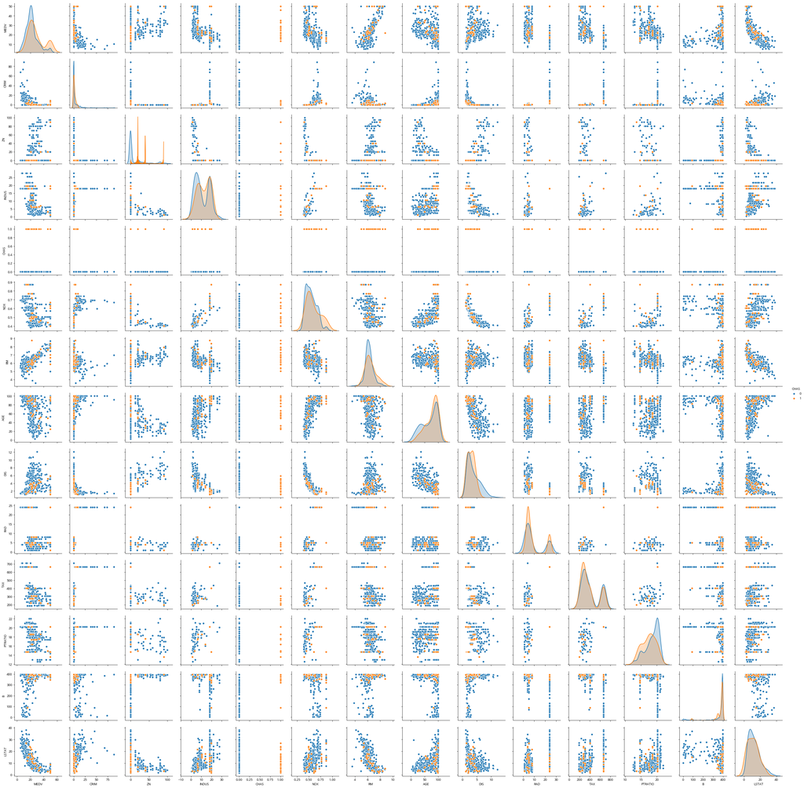

```python
sns.pairplot(ds_bo,hue="CHAS")
#CHAS강의 경우 1일 경우 그래프 분포가 다름
#특정 집값 구간에서 절단 현상이 일어나며, 다른 그룹의 형태
#일반적으로 비싼 집의 경우 CHAS일 확률이 큼
```

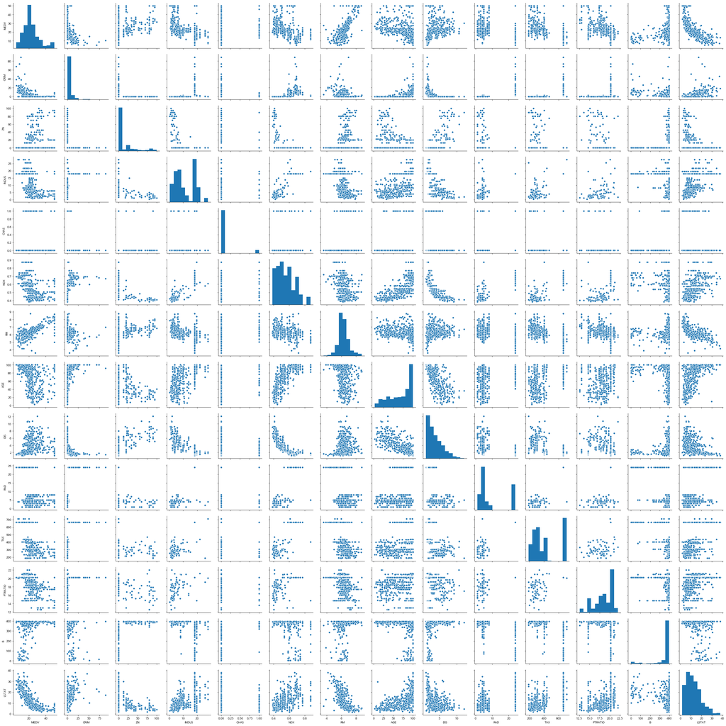

```python
sns.pairplot(ds_bo)
#LSTAT과 MEDV는 음의 상관관계
#PTRATIO와 MEDV는 음의 상관관계 : 상식적이지 않음, 학생당 교사가 많을수록 가격이 더 싸다?
#미국 보스턴 교육, 교사비율 검토 필요
#RM과 MEDV는 강한 양의 상관관계
#INDUS 공업지역 비율은 MEDV와 음의 상관관계
#NOX가 음의 상관관계 // 구간 주의
```